# Model Predictions & CV Supporting Material

## [Tidy Tuesday Spotify Dataset](https://github.com/rfordatascience/tidytuesday/tree/main/data/2020/2020-01-21)

Author: Ashley Kennedy

## Import Modules and Data

```python
import numpy as np
import pandas as pd
import matplotlib.pyplot as plt
import seaborn as sns
import statsmodels.formula.api as smf
```

```python
from sklearn.model_selection import KFold
```

```python
from sklearn.metrics import r2_score
```

```python
spotify_copy = pd.read_csv('spotify_copy.csv')
```

```python
fit_res = pd.read_csv('fit_res.csv')
```

## Predictions

I will make predictions with two models:

1. The model with all inputs and linear additive features
2. The best model on the training set

```python
formula_list = [
    # intercept only model
    'y ~ 1',
    # categorical inputs with additive features
    'y ~ playlist_genre + mode + key + release_month + bin_year',
    # continuous inputs with linear additive features
    'y ~ danceability + energy + loudness + log_speechiness + logit_acousticness + instrumentalness + sqrt_liveness + valence + tempo + duration_ms',
    # all inputs with linear additive features
    'y ~ playlist_genre + mode + key + release_month + bin_year + danceability + energy + loudness + log_speechiness + logit_acousticness + instrumentalness + sqrt_liveness + valence + tempo + duration_ms',
    # continuous inputs with linear main effect and pair-wise interactions
    'y ~ (danceability + energy + loudness + log_speechiness + logit_acousticness + instrumentalness + sqrt_liveness + valence + tempo + duration_ms) ** 2',
    # interact the categorical inputs and the continuous inputs
    'y ~ (playlist_genre + mode + key + release_month + bin_year) * (danceability + energy + loudness + log_speechiness + logit_acousticness + instrumentalness + sqrt_liveness + valence + tempo + duration_ms)',
    # linear additive features and interaction between playlist_genre, energy, and loudness as seen by relative correlation
    'y ~ (playlist_genre * loudness * energy)',
    # pairwise interactions among categorical and continuous inputs, with linear additive features
    'y ~ (playlist_genre + loudness + energy) ** 2 + mode + key + danceability + valence + tempo'
    ]
```

```python
mod_a = smf.ols(formula=formula_list[3], data=spotify_copy).fit()
```

```python
mod_b = smf.ols(formula=formula_list[5], data=spotify_copy).fit()
```

First, I will create data sets to support visualizating the predictions.

For my first grid, I will identify the continuous input that is the most important based on statistically significant coefficients.

```python
fit_res['abs_estimate'] = np.abs(fit_res.estimate)
```

```python
fit_res.loc[ fit_res.groupby('mod_num')['abs_estimate'].idxmax(), ['mod_num', 'abs_estimate', 'feature'] ].sort_index()
```

|  | mod_num | abs_estimate | feature |
| --- | --- | --- | --- |
| 0 | 0 | 0.836897 | Intercept |
| 1 | 1 | 2.240168 | Intercept |
| 33 | 2 | 1.822219 | energy |
| 73 | 3 | 1.692845 | energy |
| 84 | 4 | 2.260466 | energy |
| 167 | 5 | 2.537747 | bin_year[T.recent] |
| 480 | 6 | 3.026023 | energy |
| 493 | 7 | 2.667424 | playlist_genre[T.latin] |

### Visualization Grid 1

For my first visualization grid, I will apply `np.linspace()` with 101 unique values between the minimum and maximum value in the continuous variable `energy` and use the central values (mean and median) to the remaining continuous variables. The categorical variables will also be used, but they will only use the most frequent category.

I chose to use different values for `energy` as I feel that this is the most influential continuous variable in the data.

```python
input_grid_a = pd.DataFrame([

    (genre, mode, key, month, year, dance, energy, loud, speech, acoustic, instr, live, val, tempo, ms)

    # most frequent categorical inputs
    for genre in spotify_copy['playlist_genre'].mode()
    for mode in spotify_copy['mode'].mode()
    for key in spotify_copy['key'].mode()
    for month in spotify_copy['release_month'].mode()
    for year in spotify_copy['bin_year'].mode()

    # continuous variables
    for dance in [spotify_copy.danceability.mean()]
    for energy in np.linspace(spotify_copy.energy.min(), spotify_copy.energy.max(), num=101)
    for loud in [spotify_copy.loudness.mean()]
    for speech in [spotify_copy.log_speechiness.median()]
    for acoustic in [spotify_copy.logit_acousticness.median()]
    for instr in [spotify_copy.instrumentalness.median()]
    for live in [spotify_copy.sqrt_liveness.median()]
    for val in [spotify_copy.valence.mean()]
    for tempo in [spotify_copy.tempo.mean()]
    for ms in [spotify_copy.duration_ms.mean()]

                            ],

                            columns=[
                                'playlist_genre', 'mode', 'key', 'release_month', 'bin_year', 'danceability', 'energy', 'loudness', 'log_speechiness', 'logit_acousticness', 'instrumentalness', 'sqrt_liveness', 'valence', 'tempo', 'duration_ms'
                                ])
```

```python
input_grid_a.info()
```

```
<class 'pandas.core.frame.DataFrame'>
RangeIndex: 101 entries, 0 to 100
Data columns (total 15 columns):
 #   Column              Non-Null Count  Dtype
---  ------              --------------  -----
 0   playlist_genre      101 non-null    object
 1   mode                101 non-null    object
 2   key                 101 non-null    object
 3   release_month       101 non-null    int64
 4   bin_year            101 non-null    object
 5   danceability        101 non-null    float64
 6   energy              101 non-null    float64
 7   loudness            101 non-null    float64
 8   log_speechiness     101 non-null    float64
 9   logit_acousticness  101 non-null    float64
 10  instrumentalness    101 non-null    float64
 11  sqrt_liveness       101 non-null    float64
 12  valence             101 non-null    float64
 13  tempo               101 non-null    float64
 14  duration_ms         101 non-null    float64
dtypes: float64(10), int64(1), object(4)
memory usage: 12.0+ KB
```

```python
input_grid_a.nunique()
```

```
playlist_genre          1
mode                    1
key                     1
release_month           1
bin_year                1
danceability            1
energy                101
loudness                1
log_speechiness         1
logit_acousticness      1
instrumentalness        1
sqrt_liveness           1
valence                 1
tempo                   1
duration_ms             1
dtype: int64
```

I will now create a hard copy of `input_grid00`.

```python
dfviz_a = input_grid_a.copy()
```

**Predictions on `mod_00`:**

```python
predictions_a = mod_a.get_prediction(dfviz_a)
```

```python
pred_summary_a = predictions_a.summary_frame()
```

```python
pred_summary_a
```

|  | mean | mean_se | mean_ci_lower | mean_ci_upper | obs_ci_lower | obs_ci_upper |
| --- | --- | --- | --- | --- | --- | --- |
| 0 | -0.003920 | 0.093996 | -0.188154 | 0.180315 | -4.160268 | 4.152429 |
| 1 | -0.020848 | 0.093071 | -0.203271 | 0.161575 | -4.177116 | 4.135421 |
| 2 | -0.037776 | 0.092151 | -0.218395 | 0.142842 | -4.193966 | 4.118414 |
| 3 | -0.054705 | 0.091234 | -0.233527 | 0.124117 | -4.210817 | 4.101408 |
| 4 | -0.071633 | 0.090321 | -0.248666 | 0.105400 | -4.227668 | 4.084403 |
| ... | ... | ... | ... | ... | ... | ... |
| 96 | -1.629042 | 0.056822 | -1.740415 | -1.517668 | -5.782798 | 2.524715 |
| 97 | -1.645970 | 0.057335 | -1.758348 | -1.533592 | -5.799754 | 2.507814 |
| 98 | -1.662898 | 0.057864 | -1.776314 | -1.549483 | -5.816710 | 2.490913 |
| 99 | -1.679827 | 0.058409 | -1.794310 | -1.565344 | -5.833668 | 2.474014 |
| 100 | -1.696755 | 0.058969 | -1.812337 | -1.581174 | -5.850627 | 2.457116 |

101 rows × 6 columns

```python
sns.set_style('whitegrid')
```

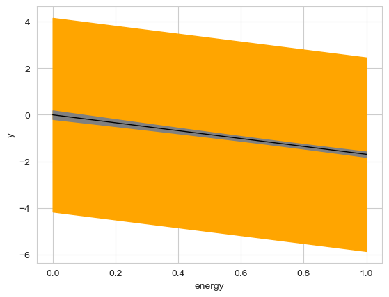

```python
fig, ax = plt.subplots()

# prediction interval
ax.fill_between(dfviz_a.energy,
                pred_summary_a.obs_ci_lower, pred_summary_a.obs_ci_upper,
                facecolor='orange', edgecolor='orange')

# confidence interval
ax.fill_between(dfviz_a.energy,
                pred_summary_a.mean_ci_lower, pred_summary_a.mean_ci_upper,
                facecolor='grey', edgecolor='grey')

# average output line
ax.plot(dfviz_a.energy, pred_summary_a['mean'], color='k', linewidth=1)

# set labels
ax.set_xlabel('energy')
ax.set_ylabel('y')

plt.show()
```

The confidence interval (grey ribbon) is very close to the trend line, suggesting that the model estimates the mean response very accurately across the observed range of `energy`.

In contrast, the prediction interval (orange ribbon) is considerably wider. Although we are able to estimate the average effect of `energy` with high accuracy, there is much more uncertainty when predicting the popularity score of any new track data and we are not as confident that the data will be close to the trend line.

**Predictions on `mod_01`:**

```python
predictions_b = mod_b.get_prediction(dfviz_a)
```

```python
pred_summary_b = predictions_b.summary_frame()
```

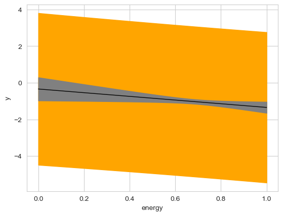

```python
fig, ax = plt.subplots()

# prediction interval
ax.fill_between(dfviz_a.energy,
                pred_summary_b.obs_ci_lower, pred_summary_b.obs_ci_upper,
                facecolor='orange', edgecolor='orange')

# confidence interval
ax.fill_between(dfviz_a.energy,
                pred_summary_b.mean_ci_lower, pred_summary_b.mean_ci_upper,
                facecolor='grey', edgecolor='grey')

# average output line
ax.plot(dfviz_a.energy, pred_summary_b['mean'], color='k', linewidth=1)

# set labels
ax.set_xlabel('energy')
ax.set_ylabel('y')

plt.show()
```

The trend line and prediction intervals of `mod_01` appear to be similar to those of `mod_00`, but there are a few key differences. The slope in `mod_00` is slightly steeper, while `mod_01` shows a shallower negative relationship between `energy` and the `y`. In addition, the intercept for `mod_00` is closer to zero, whereas the intercept for `mod_01` lies slightly below zero. This reflects the differences in how each model accounts for other predictors.

The confidence band in `mod_01` is wider than in `mod_00`, suggesting greater uncertainty in the estimated mean response for a given value of energy. However, the prediction interval remains wide in both models, which is expected, as it incorporates the full variability of individual observations rather than just estimation uncertainty.

Overall, both models are good at explaining overall patterns, such as how `energy` relates to `y`, but predictions are much less certain. As a result, these models are better used for understanding trends rather than making accurate predictions.

### Visualization Grid 2

My second visualization grid will follow the same rules as the first, except I will now utilize two more of the most important inputs based on the statistically significant coefficients in my models.

I will still use `energy` with 101 unique values just as the first grid, but now I will include `danceability` and `playlist_genre`, as they are commonly found in the top 3 highest magnitudes in many of the models.

```python
fit_res.loc[ fit_res['pvalue < 0.05'] == True ].\
    sort_values(['mod_num', 'abs_estimate'], ascending=[True, False]).\
    groupby('mod_num').head(3).loc[:, ['mod_num', 'abs_estimate', 'feature']]
```

|  | mod_num | abs_estimate | feature |
| --- | --- | --- | --- |
| 0 | 0 | 0.836897 | Intercept |
| 1 | 1 | 2.240168 | Intercept |
| 3 | 1 | 0.985323 | playlist_genre[T.pop] |
| 6 | 1 | 0.948655 | playlist_genre[T.rock] |
| 33 | 2 | 1.822219 | energy |
| 31 | 2 | 1.669544 | Intercept |
| 37 | 2 | 0.727493 | instrumentalness |
| 73 | 3 | 1.692845 | energy |
| 47 | 3 | 0.934853 | playlist_genre[T.rock] |
| 72 | 3 | 0.820592 | danceability |
| 84 | 4 | 2.260466 | energy |
| 83 | 4 | 2.229916 | danceability |
| 98 | 4 | 2.224472 | danceability:sqrt_liveness |
| 167 | 5 | 2.537747 | bin_year[T.recent] |
| 139 | 5 | 2.478242 | playlist_genre[T.latin] |
| 142 | 5 | 2.281159 | playlist_genre[T.rap] |
| 480 | 6 | 3.026023 | energy |
| 469 | 6 | 1.756411 | playlist_genre[T.latin] |
| 485 | 6 | 1.684904 | playlist_genre[T.rock]:energy |
| 493 | 7 | 2.667424 | playlist_genre[T.latin] |
| 516 | 7 | 2.484500 | energy |
| 494 | 7 | 1.683565 | playlist_genre[T.pop] |

```python
input_grid_b = pd.DataFrame([

    (genre, mode, key, month, year, dance, energy, loud, speech, acoustic, instr, live, val, tempo, ms)

    # most frequent categorical inputs
    for genre in spotify_copy['playlist_genre'].unique()
    for mode in spotify_copy['mode'].mode()
    for key in spotify_copy['key'].mode()
    for month in spotify_copy['release_month'].mode()
    for year in spotify_copy['bin_year'].mode()

    # continuous variables
    for dance in np.linspace(spotify_copy.danceability.min(), spotify_copy.danceability.max(), num=5)
    for energy in np.linspace(spotify_copy.energy.min(), spotify_copy.energy.max(), num=101)
    for loud in [spotify_copy.loudness.mean()]
    for speech in [spotify_copy.log_speechiness.median()]
    for acoustic in [spotify_copy.logit_acousticness.median()]
    for instr in [spotify_copy.instrumentalness.median()]
    for live in [spotify_copy.sqrt_liveness.median()]
    for val in [spotify_copy.valence.mean()]
    for tempo in [spotify_copy.tempo.mean()]
    for ms in [spotify_copy.duration_ms.mean()]

                            ],

                            columns=[
                                'playlist_genre', 'mode', 'key', 'release_month', 'bin_year', 'danceability', 'energy', 'loudness', 'log_speechiness', 'logit_acousticness', 'instrumentalness', 'sqrt_liveness', 'valence', 'tempo', 'duration_ms'
                                ])
```

```python
input_grid_b.info()
```

```
<class 'pandas.core.frame.DataFrame'>
RangeIndex: 3030 entries, 0 to 3029
Data columns (total 15 columns):
 #   Column              Non-Null Count  Dtype
---  ------              --------------  -----
 0   playlist_genre      3030 non-null   object
 1   mode                3030 non-null   object
 2   key                 3030 non-null   object
 3   release_month       3030 non-null   int64
 4   bin_year            3030 non-null   object
 5   danceability        3030 non-null   float64
 6   energy              3030 non-null   float64
 7   loudness            3030 non-null   float64
 8   log_speechiness     3030 non-null   float64
 9   logit_acousticness  3030 non-null   float64
 10  instrumentalness    3030 non-null   float64
 11  sqrt_liveness       3030 non-null   float64
 12  valence             3030 non-null   float64
 13  tempo               3030 non-null   float64
 14  duration_ms         3030 non-null   float64
dtypes: float64(10), int64(1), object(4)
memory usage: 355.2+ KB
```

```python
input_grid_b.nunique()
```

```
playlist_genre          6
mode                    1
key                     1
release_month           1
bin_year                1
danceability            5
energy                101
loudness                1
log_speechiness         1
logit_acousticness      1
instrumentalness        1
sqrt_liveness           1
valence                 1
tempo                   1
duration_ms             1
dtype: int64
```

I will once again create a hard copy of the input grid and this time assign it to `dfviz01` and add a new column for predictions.

```python
dfviz_b = input_grid_b.copy()
```

```python
dfviz_b['pred_a'] = mod_a.predict(input_grid_b)
```

```python
dfviz_b['pred_b'] = mod_b.predict(input_grid_b)
```

```python
dfviz_b
```

|  | playlist_genre | mode | key | release_month | bin_year | danceability | energy | loudness | log_speechiness | logit_acousticness | instrumentalness | sqrt_liveness | valence | tempo | duration_ms | pred_a | pred_b |
| --- | --- | --- | --- | --- | --- | --- | --- | --- | --- | --- | --- | --- | --- | --- | --- | --- | --- |
| 0 | pop | major | C♯/D♭ | 1 | recent | 0.000 | 0.000175 | -6.72766 | -2.621414 | -2.432874 | 0.000016 | 0.370135 | 0.511883 | 120.92709 | 225873.606742 | 0.139633 | 0.174618 |
| 1 | pop | major | C♯/D♭ | 1 | recent | 0.000 | 0.010173 | -6.72766 | -2.621414 | -2.432874 | 0.000016 | 0.370135 | 0.511883 | 120.92709 | 225873.606742 | 0.122705 | 0.152866 |
| 2 | pop | major | C♯/D♭ | 1 | recent | 0.000 | 0.020172 | -6.72766 | -2.621414 | -2.432874 | 0.000016 | 0.370135 | 0.511883 | 120.92709 | 225873.606742 | 0.105776 | 0.131113 |
| 3 | pop | major | C♯/D♭ | 1 | recent | 0.000 | 0.030170 | -6.72766 | -2.621414 | -2.432874 | 0.000016 | 0.370135 | 0.511883 | 120.92709 | 225873.606742 | 0.088848 | 0.109361 |
| 4 | pop | major | C♯/D♭ | 1 | recent | 0.000 | 0.040168 | -6.72766 | -2.621414 | -2.432874 | 0.000016 | 0.370135 | 0.511883 | 120.92709 | 225873.606742 | 0.071920 | 0.087608 |
| ... | ... | ... | ... | ... | ... | ... | ... | ... | ... | ... | ... | ... | ... | ... | ... | ... | ... |
| 3025 | edm | major | C♯/D♭ | 1 | recent | 0.983 | 0.960007 | -6.72766 | -2.621414 | -2.432874 | 0.000016 | 0.370135 | 0.511883 | 120.92709 | 225873.606742 | -1.358246 | -1.148378 |
| 3026 | edm | major | C♯/D♭ | 1 | recent | 0.983 | 0.970005 | -6.72766 | -2.621414 | -2.432874 | 0.000016 | 0.370135 | 0.511883 | 120.92709 | 225873.606742 | -1.375174 | -1.158437 |
| 3027 | edm | major | C♯/D♭ | 1 | recent | 0.983 | 0.980004 | -6.72766 | -2.621414 | -2.432874 | 0.000016 | 0.370135 | 0.511883 | 120.92709 | 225873.606742 | -1.392103 | -1.168496 |
| 3028 | edm | major | C♯/D♭ | 1 | recent | 0.983 | 0.990002 | -6.72766 | -2.621414 | -2.432874 | 0.000016 | 0.370135 | 0.511883 | 120.92709 | 225873.606742 | -1.409031 | -1.178555 |
| 3029 | edm | major | C♯/D♭ | 1 | recent | 0.983 | 1.000000 | -6.72766 | -2.621414 | -2.432874 | 0.000016 | 0.370135 | 0.511883 | 120.92709 | 225873.606742 | -1.425959 | -1.188613 |

3030 rows × 17 columns

**Predictions on `mod_00`:**

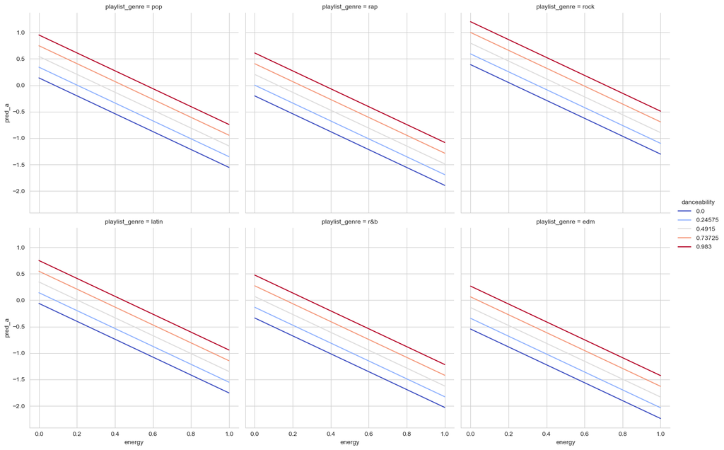

```python
sns.relplot(data=dfviz_b, x='energy', y='pred_a', kind='line',
            hue='danceability', col='playlist_genre', col_wrap=3,
            palette='coolwarm',
            estimator=None, units='danceability')

plt.show()
```

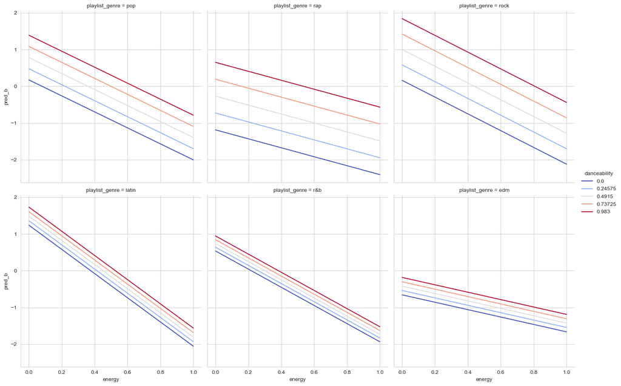

```python
sns.relplot(data=dfviz_b, x='energy', y='pred_b', kind='line',
            hue='danceability', col='playlist_genre', col_wrap=3,
            palette='coolwarm',
            estimator=None, units='danceability')

plt.show()
```

On both models, higher danceability shifts the prediction upward. In `mod_00`, the `energy` slope is the same across genres, so `playlist_genre` does not change the slope. In `mod_01`, which includes interactions, `playlist_genre` modifies the relationship with `energy`, so each genre has a different slope.

## Performance and Validation

Here, I will focus on identifying the model that will perform the BEST on NEW data. I will use cross-validation to calculate a more reliable estimate of the model performance.

I will use 3 formulas from my `formula_list`:

- The best model on the training set
- A simple model with few features
- A model with medium to high complexity

I will start by identifying the models I will use below.

Since I am using 5-fold cross-validation with regression, I need to import `KFold` from scikit-learn.

```python
kf = KFold(n_splits=5, shuffle=True, random_state=101)
```

### Execute Cross-Validation

I will now define a function that will fit and assess multiple linear regression models, as well as perform the 5-fold cross-validation. But first, I need to identify the names of the input variables as well as the name of the output variable.

```python
input_names = spotify_copy.loc[ :,
    ['playlist_genre',
    'danceability',
    'energy',
    'key',
    'loudness',
    'mode',
    'instrumentalness',
    'valence',
    'tempo',
    'duration_ms',
    'release_month',
    'log_speechiness',
    'sqrt_liveness',
    'bin_year',
    'logit_acousticness']
].copy().columns.to_list()
```

```python
output_name = 'y'
```

```python
def train_and_test_linear_with_cv(mod_name, a_formula, data_df, x_names, y_name, cv, threshold=0.5):
    # separate the inputs and the output
    input_df = data_df.loc[ :, x_names ].copy()

    # initialize the performance metric storage lists
    train_res = []
    test_res = []

    # SPLIT the data and iterate over the folds
    for train_id, test_id in cv.split( input_df.to_numpy(), data_df[ y_name ].to_numpy() ):
        # subset the training and test splits within each fold
        train_data = data_df.iloc[ train_id, : ].copy()
        test_data = data_df.iloc[ test_id, : ].copy()

        # FIT the model on the TRAINING data within the current FOLD
        a_mod = smf.ols(formula=a_formula, data=train_data).fit()

        # PREDICT the TRAINING within each FOLD
        train_copy = train_data.copy()
        train_copy['pred'] = a_mod.predict( train_data )

        # PREDICT the TESTING within each fold
        test_copy = test_data.copy()
        test_copy['pred'] = a_mod.predict( test_data )

        # calculate the PERFORMANCE METRIC on the TRAINING SET within the FOLD
        train_res.append( r2_score(train_copy[y_name], train_copy['pred']) )

        # calculate the PERFORMANCE METRIC on the TESTING SET within the FOLD
        test_res.append( r2_score(test_copy[y_name], test_copy['pred']) )

    # book keeping to store the metrics
    train_df = pd.DataFrame({'rsquared': train_res})
    train_df['from_set'] = 'training'
    train_df['fold_id'] = train_df.index + 1

    test_df = pd.DataFrame({'rsquared': test_res})
    test_df['from_set'] = 'testing'
    test_df['fold_id'] = test_df.index + 1

    # combine the splits together
    res_df = pd.concat( [train_df, test_df], ignore_index=True )

    # add information about the model
    res_df['model_name'] = mod_name
    res_df['model_formula'] = a_formula
    res_df['num_coefs'] = len( a_mod.params )
    res_df['threshold'] = threshold

    return res_df
```

Best model on the training set:

```python
train_and_test_linear_with_cv(5, a_formula=formula_list[5], data_df=spotify_copy, x_names=input_names, y_name=output_name, cv=kf)
```

|  | rsquared | from_set | fold_id | model_name | model_formula | num_coefs | threshold |
| --- | --- | --- | --- | --- | --- | --- | --- |
| 0 | 0.105388 | training | 1 | 5 | y ~ (playlist_genre + mode + key + release_mon... | 220 | 0.5 |
| 1 | 0.107544 | training | 2 | 5 | y ~ (playlist_genre + mode + key + release_mon... | 220 | 0.5 |
| 2 | 0.104354 | training | 3 | 5 | y ~ (playlist_genre + mode + key + release_mon... | 220 | 0.5 |
| 3 | 0.109228 | training | 4 | 5 | y ~ (playlist_genre + mode + key + release_mon... | 220 | 0.5 |
| 4 | 0.107510 | training | 5 | 5 | y ~ (playlist_genre + mode + key + release_mon... | 220 | 0.5 |
| 5 | 0.095159 | testing | 1 | 5 | y ~ (playlist_genre + mode + key + release_mon... | 220 | 0.5 |
| 6 | 0.086393 | testing | 2 | 5 | y ~ (playlist_genre + mode + key + release_mon... | 220 | 0.5 |
| 7 | 0.099852 | testing | 3 | 5 | y ~ (playlist_genre + mode + key + release_mon... | 220 | 0.5 |
| 8 | 0.078579 | testing | 4 | 5 | y ~ (playlist_genre + mode + key + release_mon... | 220 | 0.5 |
| 9 | 0.087211 | testing | 5 | 5 | y ~ (playlist_genre + mode + key + release_mon... | 220 | 0.5 |

Simple model with few features:

```python
train_and_test_linear_with_cv(6, a_formula=formula_list[6], data_df=spotify_copy, x_names=input_names, y_name=output_name, cv=kf)
```

|  | rsquared | from_set | fold_id | model_name | model_formula | num_coefs | threshold |
| --- | --- | --- | --- | --- | --- | --- | --- |
| 0 | 0.050928 | training | 1 | 6 | y ~ (playlist_genre * loudness * energy) | 24 | 0.5 |
| 1 | 0.050901 | training | 2 | 6 | y ~ (playlist_genre * loudness * energy) | 24 | 0.5 |
| 2 | 0.049193 | training | 3 | 6 | y ~ (playlist_genre * loudness * energy) | 24 | 0.5 |
| 3 | 0.050591 | training | 4 | 6 | y ~ (playlist_genre * loudness * energy) | 24 | 0.5 |
| 4 | 0.050935 | training | 5 | 6 | y ~ (playlist_genre * loudness * energy) | 24 | 0.5 |
| 5 | 0.046689 | testing | 1 | 6 | y ~ (playlist_genre * loudness * energy) | 24 | 0.5 |
| 6 | 0.047178 | testing | 2 | 6 | y ~ (playlist_genre * loudness * energy) | 24 | 0.5 |
| 7 | 0.053825 | testing | 3 | 6 | y ~ (playlist_genre * loudness * energy) | 24 | 0.5 |
| 8 | 0.048642 | testing | 4 | 6 | y ~ (playlist_genre * loudness * energy) | 24 | 0.5 |
| 9 | 0.047177 | testing | 5 | 6 | y ~ (playlist_genre * loudness * energy) | 24 | 0.5 |

Large model with medium to high complexity:

```python
train_and_test_linear_with_cv(4, a_formula=formula_list[4], data_df=spotify_copy, x_names=input_names, y_name=output_name, cv=kf)
```

|  | rsquared | from_set | fold_id | model_name | model_formula | num_coefs | threshold |
| --- | --- | --- | --- | --- | --- | --- | --- |
| 0 | 0.068636 | training | 1 | 4 | y ~ (danceability + energy + loudness + log_sp... | 56 | 0.5 |
| 1 | 0.067937 | training | 2 | 4 | y ~ (danceability + energy + loudness + log_sp... | 56 | 0.5 |
| 2 | 0.065862 | training | 3 | 4 | y ~ (danceability + energy + loudness + log_sp... | 56 | 0.5 |
| 3 | 0.071165 | training | 4 | 4 | y ~ (danceability + energy + loudness + log_sp... | 56 | 0.5 |
| 4 | 0.068272 | training | 5 | 4 | y ~ (danceability + energy + loudness + log_sp... | 56 | 0.5 |
| 5 | 0.062857 | testing | 1 | 4 | y ~ (danceability + energy + loudness + log_sp... | 56 | 0.5 |
| 6 | 0.066102 | testing | 2 | 4 | y ~ (danceability + energy + loudness + log_sp... | 56 | 0.5 |
| 7 | 0.074422 | testing | 3 | 4 | y ~ (danceability + energy + loudness + log_sp... | 56 | 0.5 |
| 8 | 0.052489 | testing | 4 | 4 | y ~ (danceability + energy + loudness + log_sp... | 56 | 0.5 |
| 9 | 0.064631 | testing | 5 | 4 | y ~ (danceability + energy + loudness + log_sp... | 56 | 0.5 |

```python
cv_formula_list = [formula_list[5], formula_list[6], formula_list[4]]
```

```python
results_list = []

for m in range(len(cv_formula_list)):
    results_list.append(train_and_test_linear_with_cv(m, cv_formula_list[m], data_df=spotify_copy, x_names=input_names, y_name=output_name, cv=kf))
```

```python
cv_results = pd.concat(results_list, ignore_index=True)
```

```python
cv_results
```

|  | rsquared | from_set | fold_id | model_name | model_formula | num_coefs | threshold |
| --- | --- | --- | --- | --- | --- | --- | --- |
| 0 | 0.105388 | training | 1 | 0 | y ~ (playlist_genre + mode + key + release_mon... | 220 | 0.5 |
| 1 | 0.107544 | training | 2 | 0 | y ~ (playlist_genre + mode + key + release_mon... | 220 | 0.5 |
| 2 | 0.104354 | training | 3 | 0 | y ~ (playlist_genre + mode + key + release_mon... | 220 | 0.5 |
| 3 | 0.109228 | training | 4 | 0 | y ~ (playlist_genre + mode + key + release_mon... | 220 | 0.5 |
| 4 | 0.107510 | training | 5 | 0 | y ~ (playlist_genre + mode + key + release_mon... | 220 | 0.5 |
| 5 | 0.095159 | testing | 1 | 0 | y ~ (playlist_genre + mode + key + release_mon... | 220 | 0.5 |
| 6 | 0.086393 | testing | 2 | 0 | y ~ (playlist_genre + mode + key + release_mon... | 220 | 0.5 |
| 7 | 0.099852 | testing | 3 | 0 | y ~ (playlist_genre + mode + key + release_mon... | 220 | 0.5 |
| 8 | 0.078579 | testing | 4 | 0 | y ~ (playlist_genre + mode + key + release_mon... | 220 | 0.5 |
| 9 | 0.087211 | testing | 5 | 0 | y ~ (playlist_genre + mode + key + release_mon... | 220 | 0.5 |
| 10 | 0.050928 | training | 1 | 1 | y ~ (playlist_genre * loudness * energy) | 24 | 0.5 |
| 11 | 0.050901 | training | 2 | 1 | y ~ (playlist_genre * loudness * energy) | 24 | 0.5 |
| 12 | 0.049193 | training | 3 | 1 | y ~ (playlist_genre * loudness * energy) | 24 | 0.5 |
| 13 | 0.050591 | training | 4 | 1 | y ~ (playlist_genre * loudness * energy) | 24 | 0.5 |
| 14 | 0.050935 | training | 5 | 1 | y ~ (playlist_genre * loudness * energy) | 24 | 0.5 |
| 15 | 0.046689 | testing | 1 | 1 | y ~ (playlist_genre * loudness * energy) | 24 | 0.5 |
| 16 | 0.047178 | testing | 2 | 1 | y ~ (playlist_genre * loudness * energy) | 24 | 0.5 |
| 17 | 0.053825 | testing | 3 | 1 | y ~ (playlist_genre * loudness * energy) | 24 | 0.5 |
| 18 | 0.048642 | testing | 4 | 1 | y ~ (playlist_genre * loudness * energy) | 24 | 0.5 |
| 19 | 0.047177 | testing | 5 | 1 | y ~ (playlist_genre * loudness * energy) | 24 | 0.5 |
| 20 | 0.068636 | training | 1 | 2 | y ~ (danceability + energy + loudness + log_sp... | 56 | 0.5 |
| 21 | 0.067937 | training | 2 | 2 | y ~ (danceability + energy + loudness + log_sp... | 56 | 0.5 |
| 22 | 0.065862 | training | 3 | 2 | y ~ (danceability + energy + loudness + log_sp... | 56 | 0.5 |
| 23 | 0.071165 | training | 4 | 2 | y ~ (danceability + energy + loudness + log_sp... | 56 | 0.5 |
| 24 | 0.068272 | training | 5 | 2 | y ~ (danceability + energy + loudness + log_sp... | 56 | 0.5 |
| 25 | 0.062857 | testing | 1 | 2 | y ~ (danceability + energy + loudness + log_sp... | 56 | 0.5 |
| 26 | 0.066102 | testing | 2 | 2 | y ~ (danceability + energy + loudness + log_sp... | 56 | 0.5 |
| 27 | 0.074422 | testing | 3 | 2 | y ~ (danceability + energy + loudness + log_sp... | 56 | 0.5 |
| 28 | 0.052489 | testing | 4 | 2 | y ~ (danceability + energy + loudness + log_sp... | 56 | 0.5 |
| 29 | 0.064631 | testing | 5 | 2 | y ~ (danceability + energy + loudness + log_sp... | 56 | 0.5 |

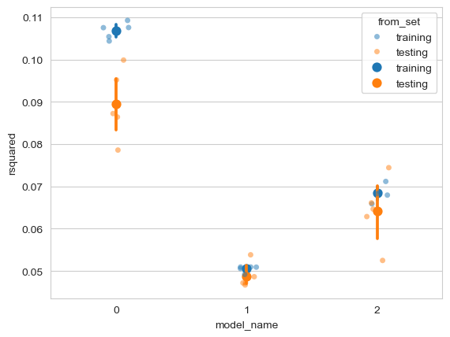

```python
fig, ax = plt.subplots()

sns.stripplot(data=cv_results, x='model_name', y='rsquared', hue='from_set', alpha=0.5, ax=ax)

sns.pointplot(data=cv_results, x='model_name', y='rsquared', hue='from_set', linestyle='none', ax=ax)

plt.show()
```